# Assignment E

## Instructions

1. You may talk to a friend, discuss the questions and potential directions for solving them. However, you need to write your own solutions and code separately, and not as a group activity.
2. Do not write your name on the assignment.
3. Write your code in the *Code* cells and your answer in the *Markdown* cells of the Jupyter notebook. Ensure that the solution is written neatly enough to understand and grade.
4. Use [Quarto](https://quarto.org/docs/output-formats/html-basics.html) to print the *.ipynb* file as HTML. You will need to open the command prompt, navigate to the directory containing the file, and use the command: `quarto render filename.ipynb --to html`. Submit the HTML file.
5. The assignment is worth 100 points, and is due on **Tuesday, 7th March 2023 at 11:59 pm**.
6. **Five points are properly formatting the assignment**. The breakdown is as follows:
- Must be an HTML file rendered using Quarto (1 pt). *If you have a Quarto issue, you must mention the issue & quote the error you get when rendering using Quarto in the comments section of Canvas, and submit the ipynb file.*
- No name can be written on the assignment, nor can there be any indicator of the student’s identity—e.g. printouts of the working directory should not be included in the final submission (1 pt)
- There aren’t excessively long outputs of extraneous information (e.g. no printouts of entire data frames without good reason, there aren’t long printouts of which iteration a loop is on, there aren’t long sections of commented-out code, etc.) (1 pt)
- Final answers of each question are written in Markdown cells (1 pt).
- There is no piece of unnecessary / redundant code, and no unnecessary / redundant text (1 pt)

```python
from sklearn.metrics import mean_squared_error
import pandas as pd
import numpy as np
import statsmodels.formula.api as sm
import seaborn as sns
import matplotlib.pyplot as plt
import itertools
import time
from sklearn.linear_model import Ridge, RidgeCV, Lasso, LassoCV
from sklearn.preprocessing import StandardScaler
from sklearn.metrics import r2_score
from sklearn.metrics import mean_squared_error
from itertools import combinations
```

## Energy model

The datasets *ENB2012_Train.csv* and *ENB2012_Test.csv* provide data on energy analysis using 12 different building shapes simulated in Ecotect. The buildings differ with respect to the glazing area, the glazing area distribution, and the orientation, amongst other parameters. Below is the description of the data columns:

1. `X1`: Relative Compactness
2. `X2`: Surface Area
3. `X3`: Wall Area
4. `X4`: Roof Area
5. `X5`: Overall Height
6. `X6`: Orientation
7. `X7`: Glazing Area
8. `X8`: Glazing Area Distribution
9. `y1`: Heating Load

```python
ENB_train = pd.read_csv('ENB2012_Train.csv')
ENB_test = pd.read_csv('ENB2012_Test.csv')
```

### E.1.1

Suppose that we want to implement the best subset selection algorithm to find the first order predictors (`X1`-`X8`) that can predict heating load (`y1`). How many models for $E$(`y1`) are possible, if the model includes (i) one variable, (ii) three variables, and (iii) eight variables? Show your steps without running any code.

Note: The notation $E$(`y1`) means the expected value of `y1` or the mean of `y1`.

*(3 points)*

1. **For 1 variable, there are 8 possible models because we can select any variable from X1 to X8.**
2. **For 3 variables, we can choose 3 out of 8 possible predictors in 8 choose 3 ways. The calculation is 8!/(3! * (8-3)!) = 56 total models.**
3. **For 8 variables, since there are only 8 possible predictor variables only 1 model is possible.**

### E.1.2

Implement the best subset selection algorithm to find the *best* first-order predictors of heating load `y1`. Print out the model summary.

Note:

1. Use *ENB2012_Train.csv* and consider only the first-order terms.
2. Use the BIC criterion for model selection.

*(4 points)*

```python
X = ENB_train[['X1','X2','X3','X4','X5','X6','X7','X8']]
```

```python
def processSubset(predictor_subset):
    # Fit model on feature_set and calculate R-squared
    model = sm.ols('Y1~' + '+'.join(predictor_subset),data = ENB_train).fit()
    Rsquared = model.rsquared
    return {"model":model, "Rsquared":Rsquared}
```

```python
def getBest_model(k):
    #tic = time.time()
    results = []
    for combo in itertools.combinations(X.columns, k):
        results.append(processSubset((list(combo))))

    # Wrap everything up in a dataframe
    models = pd.DataFrame(results)

    # Choose the model with the highest RSS
    best_model = models.loc[models['Rsquared'].argmax()]

    #toc = time.time()
    #print("Processed", models.shape[0], "models on", k, "predictors in", (toc-tic), "seconds.")
    return best_model
```

```python
models_best = pd.DataFrame(columns=["Rsquared", "model"])

#tic = time.time()
for i in range(1,1+X.shape[1]):
    models_best.loc[i] = getBest_model(i)

#toc = time.time()
#print("Total elapsed time:", (toc-tic), "seconds.")
```

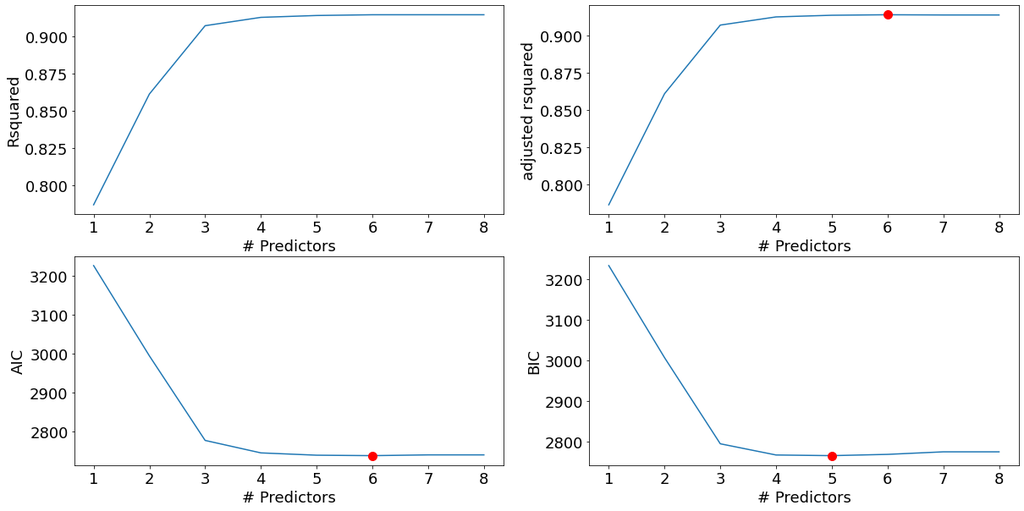

```python
def best_sub_plots():
    plt.figure(figsize=(20,10))
    plt.rcParams.update({'font.size': 18, 'lines.markersize': 10})

    # Set up a 2x2 grid so we can look at 4 plots at once
    plt.subplot(2, 2, 1)

    # We will now plot a red dot to indicate the model with the largest adjusted R^2 statistic.
    # The argmax() function can be used to identify the location of the maximum point of a vector
    plt.plot(models_best["Rsquared"])
    plt.xlabel('# Predictors')
    plt.ylabel('Rsquared')

    # We will now plot a red dot to indicate the model with the largest adjusted R^2 statistic.
    # The argmax() function can be used to identify the location of the maximum point of a vector

    rsquared_adj = models_best.apply(lambda row: row[1].rsquared_adj, axis=1)

    plt.subplot(2, 2, 2)
    plt.plot(rsquared_adj)
    plt.plot(1+rsquared_adj.argmax(), rsquared_adj.max(), "or")
    plt.xlabel('# Predictors')
    plt.ylabel('adjusted rsquared')

    # We'll do the same for AIC and BIC, this time looking for the models with the SMALLEST statistic
    aic = models_best.apply(lambda row: row[1].aic, axis=1)

    plt.subplot(2, 2, 3)
    plt.plot(aic)
    plt.plot(1+aic.argmin(), aic.min(), "or")
    plt.xlabel('# Predictors')
    plt.ylabel('AIC')

    bic = models_best.apply(lambda row: row[1].bic, axis=1)

    plt.subplot(2, 2, 4)
    plt.plot(bic)
    plt.plot(1+bic.argmin(), bic.min(), "or")
    plt.xlabel('# Predictors')
    plt.ylabel('BIC')
best_sub_plots()
```

```python
best_subset_model = models_best.loc[5,'model']
models_best.loc[5,'model'].summary()
```

OLS Regression Results

| Dep. Variable: | Y1 | R-squared: | 0.914 |
| --- | --- | --- | --- |
| Model: | OLS | Adj. R-squared: | 0.914 |
| Method: | Least Squares | F-statistic: | 1144. |
| Date: | Tue, 07 Mar 2023 | Prob (F-statistic): | 2.87e-283 |
| Time: | 20:27:35 | Log-Likelihood: | -1363.5 |
| No. Observations: | 542 | AIC: | 2739. |
| Df Residuals: | 536 | BIC: | 2765. |
| Df Model: | 5 |  |  |
| Covariance Type: | nonrobust |  |  |

|  | coef | std err | t | P>\|t\| | [0.025 | 0.975] |
| --- | --- | --- | --- | --- | --- | --- |
| Intercept | 46.1893 | 5.212 | 8.862 | 0.000 | 35.950 | 56.428 |
| X1 | -45.8814 | 2.567 | -17.876 | 0.000 | -50.923 | -40.839 |
| X4 | -0.1078 | 0.014 | -7.539 | 0.000 | -0.136 | -0.080 |
| X5 | 4.7438 | 0.318 | 14.902 | 0.000 | 4.118 | 5.369 |
| X7 | 20.1466 | 0.990 | 20.357 | 0.000 | 18.203 | 22.091 |
| X8 | 0.2421 | 0.086 | 2.809 | 0.005 | 0.073 | 0.411 |

| Omnibus: | 9.613 | Durbin-Watson: | 0.869 |
| --- | --- | --- | --- |
| Prob(Omnibus): | 0.008 | Jarque-Bera (JB): | 15.883 |
| Skew: | -0.031 | Prob(JB): | 0.000356 |
| Kurtosis: | 3.836 | Cond. No. | 7.80e+03 |

Notes:  
[1] Standard Errors assume that the covariance matrix of the errors is correctly specified.  
[2] The condition number is large, 7.8e+03. This might indicate that there are  
strong multicollinearity or other numerical problems.

### E.1.3

Should $R$-squared be used to select from among a set of models with different numbers of predictors? Justify your answer.

*(1 point for answer, 2 points for justification)*

#### No. This is because R-squared can increase as the number of predictors in the model increases, even if the added predictors are not significant predictors of the targeted outcome variable.

### E.1.4

Calculate the RMSE of the model found in E.2. Compare it with the RMSE of the model using all first-order predictors. You will find that the two RMSEs are similar. Seems like the best subset model didn’t help improve prediction.

1. Why did the best subset model not help improve prediction accuracy as compared to the model with all the predictors?
2. Does the best subset model provide a more accurate inference as compared to the model with all the predictors? Why or why npt?

Hint: **V**ery **I**mportant **F**act!

*(2 points for computing the RMSEs, 3 + 3 points for justifications)*

```python
pred_y = best_subset_model.predict(ENB_test)
np.sqrt(((pred_y - ENB_test.Y1)**2).mean())
```

```
2.778167195091468
```

```python
model = sm.ols('Y1~' + '+'.join(X.columns),data = ENB_train).fit()
pred_y = model.predict(ENB_test)
np.sqrt(((pred_y - ENB_test.Y1)**2).mean())
```

```
2.774159872402807
```

```python
X_subset = ENB_train[['X1','X4','X5','X7','X8']]
from statsmodels.stats.outliers_influence import variance_inflation_factor
from statsmodels.tools.tools import add_constant
X_subset = add_constant(X_subset)
vif_data = pd.DataFrame()
vif_data["feature"] = X_subset.columns

for i in range(len(X_subset.columns)):
    vif_data.loc[i,'VIF'] = variance_inflation_factor(X_subset.values, i)

vif_data
```

|  | feature | VIF |
| --- | --- | --- |
| 0 | const | 1623.968159 |
| 1 | X1 | 4.457484 |
| 2 | X4 | 24.792621 |
| 3 | X5 | 18.546746 |
| 4 | X7 | 1.050511 |
| 5 | X8 | 1.048155 |

```python
X = add_constant(X)
vif_data = pd.DataFrame()
vif_data["feature"] = X.columns

for i in range(len(X.columns)):
    vif_data.loc[i,'VIF'] = variance_inflation_factor(X.values, i)

vif_data
```

|  | feature | VIF |
| --- | --- | --- |
| 0 | const | 3.358044e+04 |
| 1 | X1 | 1.107762e+02 |
| 2 | X2 | inf |
| 3 | X3 | inf |
| 4 | X4 | inf |
| 5 | X5 | 3.188286e+01 |
| 6 | X6 | 1.005052e+00 |
| 7 | X7 | 1.050648e+00 |
| 8 | X8 | 1.048761e+00 |

```python
n = len(best_subset_model.model.endog)
k = len(best_subset_model.params)
ll = best_subset_model.llf

aic = -2 * ll + 2 * k
bic = -2 * ll + k * np.log(n)

print("AIC:", aic)
print("BIC:", bic)
```

```
AIC: 2739.0284959498495
BIC: 2764.8000919584874
```

```python
n = len(model.model.endog)
k = len(model.params)
ll = model.llf

aic = -2 * ll + 2 * k
bic = -2 * ll + k * np.log(n)

print("AIC:", aic)
print("BIC:", bic)
```

```
AIC: 2741.8431447423677
BIC: 2780.5005387553247
```

1. **Based on the VIF calculations for the predictors used in the best subset model, predictors X4 and X5 appear to be highly correlated with each other. This means the best subset model may have issues with multicollinearity and as a result this model might be overfitting to the training model. This might explain the similarities in RMSE between the subset model and the model with all the predictors.**
2. **The best subset model and the model with all the predictors provide similar accuracy for inference. This is because both the AIC and BIC values for each model (see above) are similar to each other However, predictors X2-X4 exhibit perfect multicollinearity in the model with all the predictors. As a result, I would say the subset model provides more accurate inference despite its own multicollinearity issues.**

### E.1.5

Let us consider adding all the 2-factor interactions of the predictors in the model. Answer the following questions without running code.

1. How many predictors do we have in total?
2. Assume best subset selection is used. How many models are fitted in total?
3. Assume forward selection is used. How many models are fitted in total?
4. Assume backward selection is used. How many models are fitted in total?
5. How many models will be developed in the iteration that contains exactly 10 predictors in each model – for best subsets, fwd/bwd regression?
6. What approach would you choose for variable selection (amonst best subset, forward selection, backward selection)?

*(6 x 2 = 12 points)*

1. **number of predictors = 8 + 8(8-1)/2 = 36 total predictors.**
2. **number of models = 2^36 = 68.7 billion models.**
3. **number of models = 1 + 36(36+1)/2 = 667 models.**
4. **number of models = 667 models *same methodology as forward selection.**
5. **best subset: 2^10 = 1024 models; foward/backward selection: 1 + 10(10+1)/2 = 56 models.**
6. **I will choose to use stepwise selection in this instance since best subset selection is very computationally expensive. Further, I would choose to use backwards selection because the numnber of predictors is not greater than the sample size in the dataset, and using backwards selection has the advantage of considering the effects of all variables simulataneously.**

### E.1.6

Use forward selection to find the *best* first-order predictors and 2-factor interactions of the predictors of `y1` (Heating Load). Print out the model summary.

*(5 points)*

```python
X = ENB_train[['X1','X2','X3','X4','X5','X6','X7','X8']]
X_backup = ENB_train[['X1','X2','X3','X4','X5','X6','X7','X8']]
```

```python
for combo in itertools.combinations(X_backup.columns, 2):
    ENB_train['_'.join(combo)] = ENB_train[combo[0]]*ENB_train[combo[1]]
    ENB_test['_'.join(combo)] = ENB_test[combo[0]]*ENB_test[combo[1]]
    X.loc[:,'_'.join(combo)] = ENB_train.loc[:,'_'.join(combo)]
```

```python
def forward(predictors):

    # Pull out predictors we still need to process
    remaining_predictors = [p for p in X.columns if p not in predictors]

    #tic = time.time()

    results = []

    for p in remaining_predictors:
        results.append(processSubset(predictors+[p]))

    # Wrap everything up in a nice dataframe
    models = pd.DataFrame(results)

    # Choose the model with the highest RSS
    best_model = models.loc[models['Rsquared'].argmax()]

    #toc = time.time()
    #print("Processed ", models.shape[0], "models on", len(predictors)+1, "predictors in", (toc-tic), "seconds.")

    # Return the best model, along with some other useful information about the model
    return best_model
```

```python
def forward_selection():
    models_best = pd.DataFrame(columns=["Rsquared", "model"])

    #tic = time.time()
    predictors = []

    for i in range(1,len(X.columns)+1):
        models_best.loc[i] = forward(predictors)
        predictors = list(models_best.loc[i]["model"].params.index[1:])

    #toc = time.time()
    #print("Total elapsed time:", (toc-tic), "seconds.")
    return models_best
```

```python
models_best = forward_selection()
```

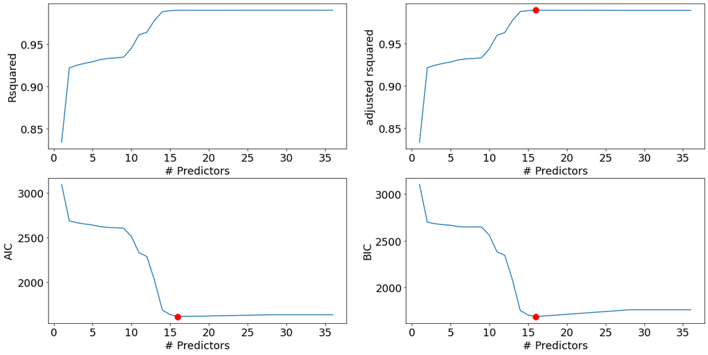

```python
best_sub_plots()
```

```python
best_fwd_reg_model = models_best['model'][16]
best_fwd_reg_model.summary()
```

OLS Regression Results

| Dep. Variable: | Y1 | R-squared: | 0.990 |
| --- | --- | --- | --- |
| Model: | OLS | Adj. R-squared: | 0.989 |
| Method: | Least Squares | F-statistic: | 3118. |
| Date: | Tue, 07 Mar 2023 | Prob (F-statistic): | 0.00 |
| Time: | 20:27:53 | Log-Likelihood: | -792.42 |
| No. Observations: | 542 | AIC: | 1619. |
| Df Residuals: | 525 | BIC: | 1692. |
| Df Model: | 16 |  |  |
| Covariance Type: | nonrobust |  |  |

|  | coef | std err | t | P>\|t\| | [0.025 | 0.975] |
| --- | --- | --- | --- | --- | --- | --- |
| Intercept | 4497.2953 | 153.516 | 29.295 | 0.000 | 4195.714 | 4798.877 |
| X3_X5 | -2.4419 | 0.317 | -7.692 | 0.000 | -3.066 | -1.818 |
| X5_X7 | -2.7764 | 0.830 | -3.346 | 0.001 | -4.407 | -1.146 |
| X1_X2 | -4.9300 | 0.652 | -7.560 | 0.000 | -6.211 | -3.649 |
| X2_X5 | 3.0027 | 0.281 | 10.698 | 0.000 | 2.451 | 3.554 |
| X3_X8 | 0.0003 | 0.000 | 0.671 | 0.502 | -0.001 | 0.001 |
| X7_X8 | -2.8188 | 0.204 | -13.814 | 0.000 | -3.220 | -2.418 |
| X7 | 84.3219 | 9.950 | 8.475 | 0.000 | 64.775 | 103.868 |
| X4_X7 | -0.2434 | 0.032 | -7.592 | 0.000 | -0.306 | -0.180 |
| X3_X4 | 0.0423 | 0.002 | 17.156 | 0.000 | 0.037 | 0.047 |
| X3 | 7.2024 | 1.546 | 4.660 | 0.000 | 4.166 | 10.239 |
| X1_X5 | 196.7862 | 36.713 | 5.360 | 0.000 | 124.663 | 268.910 |
| X5 | -1743.2087 | 101.710 | -17.139 | 0.000 | -1943.016 | -1543.401 |
| X1 | 2968.1523 | 606.145 | 4.897 | 0.000 | 1777.385 | 4158.919 |
| X2_X4 | -0.0460 | 0.004 | -12.152 | 0.000 | -0.053 | -0.039 |
| X2_X3 | -0.0047 | 0.001 | -7.500 | 0.000 | -0.006 | -0.003 |
| X1_X8 | 0.9009 | 0.191 | 4.723 | 0.000 | 0.526 | 1.276 |

| Omnibus: | 1.817 | Durbin-Watson: | 0.832 |
| --- | --- | --- | --- |
| Prob(Omnibus): | 0.403 | Jarque-Bera (JB): | 1.620 |
| Skew: | 0.095 | Prob(JB): | 0.445 |
| Kurtosis: | 3.188 | Cond. No. | 3.51e+09 |

Notes:  
[1] Standard Errors assume that the covariance matrix of the errors is correctly specified.  
[2] The condition number is large, 3.51e+09. This might indicate that there are  
strong multicollinearity or other numerical problems.

### E.1.7

Calculate the RMSE of the model found in E.1.6. Compare it with:

1. the RMSE of model you found in E.1.2 and,
2. the RMSE of the model using all the predictors and all their 2-factor interaction terms.

Among the three models (the model developed in E.1.2, the model developed in E.1.6, the model that has all the predictors and all their 2-factor interactions), discuss which model will you prefer for prediction, and which model will you prefer for inference, and why?

*(2 points for computing the RMSEs, 3 + 3 points for discussion)*

```python
pred_y = best_fwd_reg_model.predict(ENB_test)
np.sqrt(((pred_y - ENB_test.Y1)**2).mean())
```

```
1.089440469821554
```

```python
model = sm.ols('Y1~' + '+'.join(X.columns),data = ENB_train).fit()
pred_y = model.predict(ENB_test)
np.sqrt(((pred_y - ENB_test.Y1)**2).mean())
```

```
1.1088320519763366
```

```python
n = len(best_fwd_reg_model.model.endog)
k = len(best_fwd_reg_model.params)
ll = best_fwd_reg_model.llf

aic = -2 * ll + 2 * k
bic = -2 * ll + k * np.log(n)

print("AIC:", aic)
print("BIC:", bic)
```

```
AIC: 1618.8319443617906
BIC: 1691.8514663862647
```

```python
n = len(model.model.endog)
k = len(model.params)
ll = model.llf

aic = -2 * ll + 2 * k
bic = -2 * ll + k * np.log(n)

print("AIC:", aic)
print("BIC:", bic)
```

```
AIC: 1654.9335546647999
BIC: 1813.8583967180668
```

#### The models with interactions both have smaller RMSEs than the previous models, with the model developed using forward selection having a slightly lower RMSE than the model including all the predictors and their 2-factor interactions.

1. **I would prefer the forward selected model for prediction because it has the lowest RMSE meaning it is not overfit to the test dataset.**
2. **I would also prefer this same model for inference since it has lower AIC and BIC values than any of the other models. These metrics penalize models for having more parameters so a lower AIC/BIC value signifies a good balance between fit and complexity which helps with more accurate inference.**

### E.1.8

Assume that we found another dataset of 32 variabels on the same set of 768 buildings (542 for training) that we would want to add into our model. We want find the “best” model of all 40 predictors and their 2-factor interaction terms. Would you choose forward or backward selection? Justify your answer.

*(1 point for answer, 4 points for justification)*

#### This means there are 40 + 40*(40-1)/2 = 820 predictors. Because the number of predictors is greater than the sample size I would need to use forwards selection. Unlike backwards selection, forwards selection does not need to consider the full model and thus will only consider models where the number of variables is less than the sample size.

## Planetary radius model

See https://exoplanetarchive.ipac.caltech.edu (for context/source). We are using the Composite Planetary Systems dataset

```python
planet_train = pd.read_csv('train_CompositePlanetarySystems.csv')
planet_test1 = pd.read_csv('test1_CompositePlanetarySystems.csv')
planet_test2 = pd.read_csv('test2_CompositePlanetarySystems.csv')
```

### E.2.1

Say we’re interested in modeling the radius of exoplanets in kilometers, which is named as `pl_rade` in the data. Note that the variable `pl_rade` captures the radius of each planet as a proportion of Earth’s radius, which is approximately 6,378.1370 km.

Develop a linear regression model to predict `pl_rade` using all the variables in *train_CompositePlanetarySystems.csv* except `pl_name`, `disc_facility` and `disc_locale`. Find the RMSE (Root mean squared error) of the model on *test1_CompositePlanetarySystems.csv* and *test2_CompositePlanetarySystems.csv*.

*(4 points)*

```python
X = planet_train[['sy_snum','sy_pnum','cb_flag','disc_year','rv_flag','pul_flag','ptv_flag','tran_flag','ast_flag','obm_flag',
    'micro_flag','etv_flag','ima_flag','pl_controv_flag','pl_orbper','pl_dens','ttv_flag','st_teff','st_rad',
    'st_mass','st_lum','st_logg']]
```

```python
#planet_train['pl_rade'] = planet_train['pl_rade']*6378.137
#planet_test1['pl_rade'] = planet_test1['pl_rade']*6378.137
#planet_test2['pl_rade'] = planet_test2['pl_rade']*6378.137
##I'm choosing not to multiply the values by the kilometers
```

```python
model = sm.ols('pl_rade~' + '+'.join(X.columns),data = planet_train).fit()
model.summary()
```

OLS Regression Results

| Dep. Variable: | pl_rade | R-squared: | 0.724 |
| --- | --- | --- | --- |
| Model: | OLS | Adj. R-squared: | 0.719 |
| Method: | Least Squares | F-statistic: | 124.8 |
| Date: | Tue, 07 Mar 2023 | Prob (F-statistic): | 4.83e-249 |
| Time: | 20:28:02 | Log-Likelihood: | -2358.9 |
| No. Observations: | 970 | AIC: | 4760. |
| Df Residuals: | 949 | BIC: | 4862. |
| Df Model: | 20 |  |  |
| Covariance Type: | nonrobust |  |  |

|  | coef | std err | t | P>\|t\| | [0.025 | 0.975] |
| --- | --- | --- | --- | --- | --- | --- |
| Intercept | 370.5206 | 48.434 | 7.650 | 0.000 | 275.470 | 465.572 |
| sy_snum | 0.0252 | 0.297 | 0.085 | 0.932 | -0.558 | 0.608 |
| sy_pnum | -0.7530 | 0.082 | -9.157 | 0.000 | -0.914 | -0.592 |
| cb_flag | -1.9300 | 2.001 | -0.964 | 0.335 | -5.857 | 1.997 |
| disc_year | -0.1781 | 0.024 | -7.480 | 0.000 | -0.225 | -0.131 |
| rv_flag | 7.2423 | 0.265 | 27.343 | 0.000 | 6.722 | 7.762 |
| pul_flag | -4.74e-10 | 1.12e-10 | -4.229 | 0.000 | -6.94e-10 | -2.54e-10 |
| ptv_flag | 3.5059 | 4.501 | 0.779 | 0.436 | -5.327 | 12.339 |
| tran_flag | 1.1365 | 0.352 | 3.232 | 0.001 | 0.446 | 1.827 |
| ast_flag | 1.5613 | 2.059 | 0.758 | 0.448 | -2.479 | 5.601 |
| obm_flag | -0.9951 | 1.149 | -0.866 | 0.387 | -3.250 | 1.260 |
| micro_flag | -3.029e-12 | 5.12e-13 | -5.913 | 0.000 | -4.03e-12 | -2.02e-12 |
| etv_flag | 4.0156 | 5.375 | 0.747 | 0.455 | -6.533 | 14.564 |
| ima_flag | -2362.1345 | 540.655 | -4.369 | 0.000 | -3423.151 | -1301.118 |
| pl_controv_flag | -4.4229 | 2.569 | -1.722 | 0.085 | -9.464 | 0.618 |
| pl_orbper | 0.0003 | 6.73e-05 | 4.404 | 0.000 | 0.000 | 0.000 |
| pl_dens | -0.0088 | 0.009 | -0.964 | 0.335 | -0.027 | 0.009 |
| ttv_flag | 0.8794 | 0.362 | 2.432 | 0.015 | 0.170 | 1.589 |
| st_teff | 0.0005 | 0.000 | 2.860 | 0.004 | 0.000 | 0.001 |
| st_rad | -0.1803 | 0.057 | -3.182 | 0.002 | -0.291 | -0.069 |
| st_mass | 3.3632 | 0.580 | 5.803 | 0.000 | 2.226 | 4.501 |
| st_lum | -1.1531 | 0.448 | -2.572 | 0.010 | -2.033 | -0.273 |
| st_logg | -3.2476 | 0.677 | -4.796 | 0.000 | -4.576 | -1.919 |

| Omnibus: | 45.899 | Durbin-Watson: | 1.928 |
| --- | --- | --- | --- |
| Prob(Omnibus): | 0.000 | Jarque-Bera (JB): | 141.548 |
| Skew: | 0.088 | Prob(JB): | 1.83e-31 |
| Kurtosis: | 4.863 | Cond. No. | 1.15e+23 |

Notes:  
[1] Standard Errors assume that the covariance matrix of the errors is correctly specified.  
[2] The smallest eigenvalue is 4.91e-33. This might indicate that there are  
strong multicollinearity problems or that the design matrix is singular.

```python
pred_rade = model.predict(planet_test1)
np.sqrt(((pred_rade - planet_test1.pl_rade)**2).mean())
```

```
127.3659549636193
```

#### The RMSE is 127.3659549636193

```python
pred_rade = model.predict(planet_test2)
np.sqrt(((pred_rade - planet_test2.pl_rade)**2).mean())
```

```
202.66277572551496
```

#### The RMSE is 202.66277572551496

### E.2.2

Develop a ridge regression model to predict `pl_rade` using all the variables in *train_CompositePlanetarySystems.csv* except `pl_name`, `disc_facility` and `disc_locale`. What is the optimal value of the tuning parameter $\lambda$?

**Hint:** You may use the following grid of lambda values to find the optimal $\lambda$: `alphas = 10**np.linspace(2,0.5,200)*0.5`

Remember to standardize data before fitting the ridge regression model

*(5 points)*

```python
#Filtering all predictors
X = planet_train[['sy_snum','sy_pnum','cb_flag','disc_year','rv_flag','pul_flag','ptv_flag','tran_flag','ast_flag','obm_flag',
    'micro_flag','etv_flag','ima_flag','pl_controv_flag','pl_orbper','pl_dens','ttv_flag','st_teff','st_rad',
    'st_mass','st_lum','st_logg']];

#Defining a scaler object
scaler = StandardScaler()

#The scaler object will contain the mean and variance of each column (predictor) of X.
#These values will be useful to scale test data based on the same mean and variance as obtained on train data
scaler.fit(X)

#Using the scaler object (or the values of mean and variance stored in it) to standardize X (or train data)
Xstd = scaler.transform(X)
```

```python
y = planet_train.pl_rade
alphas = 10**np.linspace(2,0.5,200)*0.5
coefs = []
for a in alphas:
    ridge = Ridge(alpha = a)
    ridge.fit(Xstd, y)
    coefs.append(ridge.coef_)
ridgecv = RidgeCV(alphas = alphas,store_cv_values=True)
ridgecv.fit(Xstd, y)

#Optimal value of the tuning parameter - lambda
ridgecv.alpha_
```

```
3.221181754360687
```

#### The optimal tuning parameter is 3.221181754360687

### E.2.3

Use the optimal value of $\lambda$ found in the previous question to develop a ridge regression model. What is the RMSE of the model on *test1_CompositePlanetarySystems.csv* and *test2_CompositePlanetarySystems.csv*?

*(5 points)*

```python
ridge = Ridge(alpha = ridgecv.alpha_)
ridge.fit(Xstd, y)
a=ridge.coef_
a
```

```
array([ 0.01674792, -0.88837782, -0.11985394, -0.71744497,  3.4569394 ,
        0.        ,  0.12363732,  0.26019833,  0.16695807, -0.08130019,
        0.        ,  0.22318713,  0.00366434, -0.20956523,  0.60876113,
       -0.07349673,  0.23977841,  0.88177245, -0.52244276,  1.05162589,
       -0.69650015, -1.2706653 ])
```

```python
#Test1 dataset
Xtest_1 = planet_test1[['sy_snum','sy_pnum','cb_flag','disc_year','rv_flag','pul_flag','ptv_flag','tran_flag','ast_flag','obm_flag',
    'micro_flag','etv_flag','ima_flag','pl_controv_flag','pl_orbper','pl_dens','ttv_flag','st_teff','st_rad',
    'st_mass','st_lum','st_logg']]

#Standardizing test data
Xtest1_std = scaler.transform(Xtest_1)
```

```python
pred=ridge.predict(Xtest1_std)
np.sqrt(((pred-planet_test1.pl_rade)**2).mean())
```

```
3.218708879148547
```

```python
#Test2 dataset
Xtest_2 = planet_test2[['sy_snum','sy_pnum','cb_flag','disc_year','rv_flag','pul_flag','ptv_flag','tran_flag','ast_flag','obm_flag',
    'micro_flag','etv_flag','ima_flag','pl_controv_flag','pl_orbper','pl_dens','ttv_flag','st_teff','st_rad',
    'st_mass','st_lum','st_logg']]

#Standardizing test data
Xtest2_std = scaler.transform(Xtest_2)
```

```python
pred=ridge.predict(Xtest2_std)
np.sqrt(((pred-planet_test2.pl_rade)**2).mean())
```

```
2.9898651678534596
```

### E.2.4

Note that ridge regression has a much lower RMSE on test datasets as compared to Ordinary least squares (OLS) regression. Shrinking the coefficients has reduced the variance of the estimated coefficents with a little increase in bias, thereby improving the model fit. Appreciate it. Which are the top two predictors for which the coefficients have shrunk the most?

To answer this question, find the ridge regression estimates for $\lambda = 10^{-10}$ *(almost zero regularization)*. Treat these estimates as OLS estimates and find the predictors for which these estimates have shrunk the most as compared to the model developed in E.2.3.

*(4 points for code, 1 point for answer)*

```python
ridge = Ridge(alpha=10**-10) # Replace 0.1 with the desired lambda value

# Fit the Ridge regression model to your data
ridge.fit(Xstd, y)

# Get the estimated coefficients
beta_hat = ridge.coef_
```

```python
b=beta_hat
#df2 = pd.DataFrame(b, columns=['Non-Optimal Coefficients'])
b = pd.Series(b, name='Column1')
a = pd.Series(a, name='Column2')
```

```python
combined_df = pd.concat([a, b], axis=1, ignore_index=True)
```

```python
combined_df['difference'] = np.abs(combined_df[0] - combined_df[1])
```

```python
combined_df.sort_values('difference',ascending=False)
```

|  | 0 | 1 | difference |
| --- | --- | --- | --- |
| 14 | 0.608761 | 76.418631 | 75.809870 |
| 12 | 0.003664 | -75.804463 | 75.808127 |
| 7 | 0.260198 | 0.453724 | 0.193526 |
| 20 | -0.696500 | -0.812958 | 0.116458 |
| 21 | -1.270665 | -1.383991 | 0.113326 |
| 8 | 0.166958 | 0.070820 | 0.096138 |
| 17 | 0.881772 | 0.954692 | 0.072920 |
| 3 | -0.717445 | -0.780497 | 0.063052 |
| 11 | 0.223187 | 0.182152 | 0.041035 |
| 15 | -0.073497 | -0.086940 | 0.013444 |
| 4 | 3.456939 | 3.469238 | 0.012299 |
| 1 | -0.888378 | -0.876263 | 0.012115 |
| 6 | 0.123637 | 0.112509 | 0.011128 |
| 16 | 0.239778 | 0.229052 | 0.010726 |
| 18 | -0.522443 | -0.513427 | 0.009016 |
| 13 | -0.209565 | -0.200628 | 0.008937 |
| 0 | 0.016748 | 0.008191 | 0.008557 |
| 2 | -0.119854 | -0.123682 | 0.003828 |
| 19 | 1.051626 | 1.055440 | 0.003814 |
| 9 | -0.081300 | -0.084228 | 0.002928 |
| 10 | 0.000000 | 0.000000 | 0.000000 |
| 5 | 0.000000 | 0.000000 | 0.000000 |

```python
print(X.columns[14],",",X.columns[12])
```

```
pl_orbper , ima_flag
```

#### The top two predictors for which the coefficients have shrunk the most is pl_orbper and ima_flag.

### E.2.5

Why do you think the coefficients of the two variables identified in the previous question shrunk the most?

*(4 points for justification - including code used)*

```python
X = add_constant(X)
vif_data = pd.DataFrame()
vif_data["feature"] = X.columns

for i in range(len(X.columns)):
    vif_data.loc[i,'VIF'] = variance_inflation_factor(X.values, i)

vif_data.sort_values('VIF',ascending=False)
```

|  | feature | VIF |
| --- | --- | --- |
| 0 | const | 293592.094382 |
| 15 | pl_orbper | 37683.517115 |
| 13 | ima_flag | 37675.155715 |
| 18 | st_teff | 13.944718 |
| 21 | st_lum | 12.507339 |
| 22 | st_logg | 10.421923 |
| 12 | etv_flag | 7.440160 |
| 20 | st_mass | 4.139998 |
| 19 | st_rad | 3.257504 |
| 7 | ptv_flag | 2.610996 |
| 8 | tran_flag | 2.466560 |
| 3 | cb_flag | 2.058390 |
| 5 | rv_flag | 2.014735 |
| 14 | pl_controv_flag | 1.698968 |
| 4 | disc_year | 1.362591 |
| 10 | obm_flag | 1.183595 |
| 1 | sy_snum | 1.162755 |
| 2 | sy_pnum | 1.146094 |
| 17 | ttv_flag | 1.110245 |
| 9 | ast_flag | 1.091332 |
| 16 | pl_dens | 1.017593 |
| 6 | pul_flag | NaN |
| 11 | micro_flag | NaN |

#### The variables with the highest VIF values. meaning they are highly correlated with each other. They also happened to be the two variables that shrunk the most with ridge regression. By adding a regularization term through ridge regression, the model can reduce the influence of these highly correlated variables. This regularization shrinks the coefficient estimates towards zero, which reduces their magnitudes.

### E.2.6

Develop a lasso model to predict `pl_rade` using all the variables in *train_CompositePlanetarySystems.csv* except `pl_name`, `disc_facility` and `disc_locale`. What is the optimal value of the tuning parameter $\lambda$?

**Hint:** You may use the following grid of lambda values to find the optimal $\lambda$: `alphas = 10**np.linspace(0,-2.5,200)*0.5`

*(4 points)*

```python
alphas = 10**np.linspace(0,-2.5,200)*0.5
lassocv = LassoCV(alphas = alphas, cv = 10, max_iter = 1000000)
lassocv.fit(Xstd, y)

#Optimal value of the tuning parameter - lamda
lassocv.alpha_
```

```
0.002051329052913595
```

#### The optimal tuning parameter is: 0.002051329052913595

### E.2.7

Use the optimal value of $\lambda$ found in the previous question to develop a lasso model. What is the RMSE of the model on *test1_CompositePlanetarySystems.csv* and *test2_CompositePlanetarySystems.csv*?

*(5 points)*

```python
lasso = Lasso(alpha = lassocv.alpha_)
lasso.fit(Xstd, y)
```

```
Lasso(alpha=0.002051329052913595)
```

```python
pred=lasso.predict(Xtest1_std)
np.sqrt(((pred-planet_test1.pl_rade)**2).mean())
```

```
3.2205823819653285
```

```python
pred=lasso.predict(Xtest2_std)
np.sqrt(((pred-planet_test2.pl_rade)**2).mean())
```

```
2.9967131637090154
```

1. **The RMSE for the first test dataset is: 3.2205823819653285**
2. **The RMSE for the second test dataset is: 2.9967131637090154**

### E.2.8

Note that lasso has a much lower RMSE on test datasets as compared to Ordinary least squares (OLS) regression. Shrinking the coefficients has improved the model fit. Appreciate it. Which variables have been eliminated by lasso?

To answer this question, find the predictors whose coefficients are 0 in the lasso model.

*(2 points for code, 1 point for answer)*

```python
a= lasso.coef_
coeff_series = pd.Series(a, name='Lasso Coefficients')
```

```python
coeff_sorted = coeff_series.abs().sort_values()
coeff_sorted
```

```
10    0.000000
12    0.000000
5     0.000000
0     0.012105
15    0.071061
9     0.083005
6     0.110936
2     0.114719
8     0.166013
11    0.197494
13    0.215100
16    0.239185
7     0.269474
18    0.524817
14    0.610153
3     0.717696
20    0.730514
1     0.888101
17    0.922826
19    1.051955
21    1.297343
4     3.472807
Name: Lasso Coefficients, dtype: float64
```

```python
print(X.columns[10],",",X.columns[12],",",X.columns[5])
```

[output not shown]

## E.3 $K$-fold cross validation

We haves used *car_features_train.csv* and *car_prices_train.csv* in class notes to predict car `price`. Based on correlation with `price`, the four most relevant continuous predictors to predict car price are `year`, `mpg`, `mileage`, and `engineSize`. In this question, you will use $K$-fold cross validation to find out the relevant interactions of these predictors and the relevant interactions of the polynomial transformations of these predictors for predicting car `price`. We’ll consider quadratic and cubic transfromations of each predictor, and the interactions of these transformed predictors. For example, some of the interaction terms that you will consider are (`year`$^2$), (`year`)(`mpg`), (`year`$^2$)(`mpg`), (`year`)(`mpg`)(`mileage`), (`year`)(`mpg`$^2$)(`mileage`), (`year`)(`mpg`$^2$)(`mileage`)(`engineSize`$^3$), etc. The highest degree interaction term will be of degree 12 - (`year`$^3$)(`mpg`$^3$)(`mileage`$^3$)(`engineSize`$^3$), and the lowest degree interaction terms will be of degree two, such as (`engineSize`$^2$), (`engineSize`)(`mpg`), etc.

The algorithm to find out the relevant interactions using $K$-fold cross validation is as follows. Most of the algorithm is already coded for you. You need to code only step 2 as indicated below.

1. Start with considering interactions of degree `d` = 2:
2. **Find out the 5-fold cross validation RMSE if an interaction of degree `d` is added to the model** *(You need to code only this step)*.
3. Repeat step (2) for all possible interactions of degree `d`.
4. Include the interaction of degree `d` in the model that leads to the highest reduction in the 5-fold cross validation error as compared to the previous model *(forward stepwise selection based on K-fold cross validation)*
5. Repeat steps 2-4 until no more reduction is possible in the 5-fold cross validation RMSE.
6. If `d` = 12, then stop, otherwise increment `d` by one, and repeat steps 2-5.

The above algorithm is coded below. The algorithm calls a function `KFoldCV` to compute the 5-fold cross validation RMSE given the interaction terms already selected in the model are `selected_interactions`, and the interaction term to be tested is `interaction_being_tested`. The function must return the 5-fold cross validation RMSE if the `interaction_being_tested` is included to the model consisting of `year`, `mpg`, `mileage`, and `engineSize` as predictors in addition to the already added interactions in `selected_interactions`. The model equation for which you need to find the $5$-fold cross validation RMSE will be`'price~year+mpg+mileage+engineSize' + selected_interactions + interaction_being_tested`

You need to do the following:

1. Fill out the function `KFoldCV`.
2. Execute the code to obtain the relevant interactions in `selected_interactions`. Print out the object `selected_interactions`.
3. Fit the model with the four predictors, the `selected_interactions` and compute the RMSE on test data.

**Relevance of this question to the [linear regression prediction problem](https://www.kaggle.com/competitions/data-science-2-linear-regression-2023-bank-loans):** Once you figure out the four most useful predictors to predict `money_made_inv`, use this algorithm to find out their useful interactions. Combine the model with the EDA-based insight of developing the model only where `out_prncp_inv`>0, and you should get a RMSE of less than 400 on the public leaderboard! *(This algorithm is inspired by Victoria Shi’s solution to the linear regression prediction problem)*.

Note that this brute-force approach of finding relevant interactions may work sometimes, especially when $n>>p$ *(the number of observations are much higher than the number of predictors)*, and/or if the relationship can approximated as a linear combination of polynomial interactions. However, it is unlikely to work in case of relatively less number of observations, and in case of highly non-linear relationships that are difficult to approximate with polynomial transformations. In such problems, a few minutes spent on EDA to figure out transformations, etc. may help develop a better model than this brute-force approach. For example, EDA-based transformations helped you get a RMSE of less than $350k in question [C.1.6](https://nustat.github.io/STAT303-2-class-notes/Assignment%20C.html#section-5), while this approach gives a relatively much higher RMSE. Note that the data in C.1.6 has a relatively less number of observations.

*(10 (filling out the function) + 1 + 1 points)*

```python
import pandas as pd
import numpy as np
trainf = pd.read_csv('Car_features_train.csv')
trainp = pd.read_csv('Car_prices_train.csv')
testf = pd.read_csv('Car_features_test.csv')
testp = pd.read_csv('Car_prices_test.csv')
test = pd.merge(testf, testp)
train = pd.merge(trainf, trainp)
```

```python
# Creating a dataframe that will consist of all combinations of polynomial transformations of the
# predictors to be considered for interactions

predictor_set = ['year','mpg','engineSize','mileage']
from itertools import product
values = np.arange(0,4)
polynomial_transformations = pd.DataFrame(product(values, repeat=4), columns=predictor_set).loc[1:,]
polynomial_transformations.loc[:,'sum_degree'] = (polynomial_transformations).astype(int).sum(axis=1)
polynomial_transformations.loc[:,'count_zeros'] = (polynomial_transformations == 0).astype(int).sum(axis=1)
polynomial_transformations.sort_values(by = ['count_zeros', 'sum_degree'], ascending=[False, True], inplace=True)
polynomial_transformations.drop(columns = ['count_zeros'], inplace=True)
polynomial_transformations.reset_index(inplace = True, drop = True)
```

```python
#Setting the seed as we are shuffling the data before splitting it into K-folds
np.random.seed(123)
# Shuffling the training set before creating K folds
train = train.sample(frac=1)
k = 5 #5-fold cross validation
fold_size = int(np.round(train.shape[0]/k))
```

```python
# Fill out this function - that is all you need to do to make the code work!

# The function must return the mean 5-fold cross validation RMSE for the model
# that has the 4 individual predictors - 'year', 'mpg', 'mileage', and 'engineSize',
# the 'selected_interactions', and the 'interaction_being_tested'

# Uncomment the lines below and fill the function
def KFoldCV(selected_interactions, interaction_being_tested):
    # Define an empty list to store the RMSE values for each fold
    rmse_values = []

    for i in range(k):
        # Create the training set and validation set for this fold
        start_index = i * fold_size
        end_index = min((i+1) * fold_size, train.shape[0])
        train_fold = pd.concat([train.iloc[:start_index], train.iloc[end_index:]])
        valid_fold = train.iloc[start_index:end_index]

        # Fit a linear regression model to the training set with the specified predictors and interactions
        predictors = 'year', 'mpg', 'mileage', 'engineSize' + selected_interactions + interaction_being_tested
        #formula = 'price ~ ' + ' + '.join(predictors)
        model = sm.ols(formula='price~year+mpg+mileage+engineSize'+selected_interactions+interaction_being_tested, data=train_fold).fit()

        # Make predictions on the validation set using the fitted model
        y_pred = model.predict(valid_fold)

        # Calculate the RMSE for the validation set and append it to the list of RMSE values
        rmse = np.sqrt(((y_pred-valid_fold['price'])**2).mean())
        rmse_values.append(rmse)

    # Calculate the mean of the RMSE values and return it
    return np.mean(rmse_values)
```

```python
# This code implements the algorithm of systematically considering interactions of degree 2 and going upto
# the interaction of degree 12. For a given degree 'd' the interactions are selected greedily based on
# highest reduction in the 5-fold cross validation RMSE. Once no more reduction in the 5-fold cross validation
# RMSE is possible using interactions of degree 'd', interaction terms of the next higher degree 'd+1' are considered.

# 5-fold cross validation RMSE of the initial model with the 4 predictors of degree one
cv_previous_model = KFoldCV(selected_interactions = '', interaction_being_tested = '')
interaction_being_tested = '+'
selected_interactions = ''

# Considering interactions of degree 'd' = 2 to 12
for d in np.arange(2,13):

    # Selecting interaction terms of degree = 'd'
    degree_set = polynomial_transformations.loc[polynomial_transformations.sum_degree==d, :]

    # Initializing objects to store the interactions of degree 'd' that reduce the
    # 5-fold cross validation RMSEs as compared to the previous model
    interactions_that_reduce_KfoldCV = []; cv_degree = [];

    # Creating another DataFrame that will consist of the updated set of interactions of degree 'd' to be considered
    # as interactions that do not reduce the 5-fold cross validation RMSE will be discarded
    degree_set_updated = pd.DataFrame(columns = degree_set.columns)

    # Continue adding interactions of degree 'd' in the model until no interactions reduce
    # the 5-fold cross-validation RMSE
    while True:

        #Iterating over all possible interactions of degree 'd'
        for index, row in degree_set.iterrows():

            # Creating the formula expression for the interaction term to be tested
            for predictor in predictor_set:
                interaction_being_tested = interaction_being_tested + ('I('+predictor +'**' +\
                                         str(row[predictor]) + ')*' if row[predictor]>1 else\
                                               predictor + '*' if row[predictor]==1 else '')
            interaction_being_tested = interaction_being_tested[:-1]

            # Call the function 'KFoldCV' to find out the 5-fold cross validation error on adding the
            # interaction term being tested to the model
            cv = KFoldCV(selected_interactions, interaction_being_tested)

            # If the interaction term being tested reduces the 5-fold cross validation RMSE as compared to the
            # previous model, then consider adding it to the model
            if cv<cv_previous_model:
                interactions_that_reduce_KfoldCV.append(interaction_being_tested)
                cv_degree.append(cv)
                degree_set_updated = pd.concat([degree_set_updated, row.to_frame().T])
            interaction_being_tested = '+'
        cv_data = pd.DataFrame({'interaction':interactions_that_reduce_KfoldCV, 'cv':cv_degree})

        # Sort the interaction terms that reduce the 5-fold cross valdiation RMSE based on their respective
        # 5-fold cross validation RMSE
        cv_data.sort_values(by = 'cv', inplace = True)

        # Break the loop if no interaction of degree 'd' reduces the 5-fold cross validation RMSE as
        # compared to the previous model
        if cv_data.shape[0]==0:
            break

        # Select the interaction that corresponds to the least 5-fold cross validation RMSE
        selected_interactions = selected_interactions + cv_data.iloc[0,0]
        cv_previous_model = cv_data.iloc[0,1]
        cv_degree = []; interactions_that_reduce_KfoldCV = []
        degree_set = degree_set_updated.copy()
        degree_set_updated = pd.DataFrame(columns = degree_set.columns)

        # Print the progress after each model update, i.e., after an interaction term is selected
        print("Degree of interactions being considered:",d, ", 5-fold CV RMSE:", cv_previous_model)
```

```
Degree of interactions being considered: 2 , 5-fold CV RMSE: 9206.90196099997
Degree of interactions being considered: 2 , 5-fold CV RMSE: 8656.816425822315
Degree of interactions being considered: 2 , 5-fold CV RMSE: 8591.34227213536
Degree of interactions being considered: 2 , 5-fold CV RMSE: 8544.657805088436
Degree of interactions being considered: 2 , 5-fold CV RMSE: 8482.322266171454
Degree of interactions being considered: 2 , 5-fold CV RMSE: 8463.879301979203
Degree of interactions being considered: 2 , 5-fold CV RMSE: 8461.642878109793
Degree of interactions being considered: 3 , 5-fold CV RMSE: 8301.198053610631
Degree of interactions being considered: 3 , 5-fold CV RMSE: 8223.703387098096
Degree of interactions being considered: 3 , 5-fold CV RMSE: 8166.5032463973475
Degree of interactions being considered: 3 , 5-fold CV RMSE: 8129.219696787603
Degree of interactions being considered: 3 , 5-fold CV RMSE: 8123.852006225527
Degree of interactions being considered: 4 , 5-fold CV RMSE: 8115.550032922942
Degree of interactions being considered: 4 , 5-fold CV RMSE: 8115.31974390703
Degree of interactions being considered: 5 , 5-fold CV RMSE: 8072.419932842211
Degree of interactions being considered: 5 , 5-fold CV RMSE: 8071.736317487832
Degree of interactions being considered: 6 , 5-fold CV RMSE: 8027.471183462406
Degree of interactions being considered: 6 , 5-fold CV RMSE: 8009.271434528338
```